# Is Maryland Basketball Really That Bad at Recruiting Local Talent?

In my 2.5 years at UMD, I've regularly listened to my friends lament over how talent-rich the DMV high school basketball scene is and how UMD Basketball fails to recruit the local talent. I wanted to see if this was actually the case. Is Maryland really that bad at recruiting local talent, and how do we stack up compared to other basketball programs? More broadly, I wanted to look at the overall spatial relationship between high school basketball players and the college they ended up attending. Do all colleges have a spatial relationship with their recruits? Which ones do or do not? Ultimately, this analysis can give me better insight into the dynamics of college recruiting and whether or not I should tell my friends to stop complaining and actually be proud of Maryland Basketball's home town traditions.

## Part 1: Data Scraping - *DO NOT RUN SCRAPER: THE WEBSITE HAS CHANGED*

To find out which schools are good at recruiting local talent, I needed a dataset of college basketball recruits. 247sports.com is the leading website for tracking high school football and basketball players as they transition to college. Each year, they list the top 5, 4, and 3 star basketball recruits along with other data including their high school and college. With the locations of each recruits home town and college, I could look at the spatial relationship between colleges and their recruits.

```python
# Imports
import requests
from bs4 import BeautifulSoup
import pandas as pd
import geopandas as gpd
import matplotlib.pyplot as plt
import re
import numpy as np
from geopy.geocoders import Nominatim
from shapely.geometry import Point, LineString, Polygon
from statsmodels.stats.weightstats import ztest
import shapely
import random
```

```python
# Dictionary containing state names and abbreviations
abbrs = {
    "Alabama": "AL",
    "Alaska": "AK",
    "Arizona": "AZ",
    "Arkansas": "AR",
    "California": "CA",
    "Colorado": "CO",
    "Connecticut": "CT",
    "Delaware": "DE",
    "Florida": "FL",
    "Georgia": "GA",
    "Hawaii": "HI",
    "Idaho": "ID",
    "Illinois": "IL",
    "Indiana": "IN",
    "Iowa": "IA",
    "Kansas": "KS",
    "Kentucky": "KY",
    "Louisiana": "LA",
    "Maine": "ME",
    "Maryland": "MD",
    "Massachusetts": "MA",
    "Michigan": "MI",
    "Minnesota": "MN",
    "Mississippi": "MS",
    "Missouri": "MO",
    "Montana": "MT",
    "Nebraska": "NE",
    "Nevada": "NV",
    "New Hampshire": "NH",
    "New Jersey": "NJ",
    "New Mexico": "NM",
    "New York": "NY",
    "North Carolina": "NC",
    "North Dakota": "ND",
    "Ohio": "OH",
    "Oklahoma": "OK",
    "Oregon": "OR",
    "Pennsylvania": "PA",
    "Rhode Island": "RI",
    "South Carolina": "SC",
    "South Dakota": "SD",
    "Tennessee": "TN",
    "Texas": "TX",
    "Utah": "UT",
    "Vermont": "VT",
    "Virginia": "VA",
    "Washington": "WA",
    "West Virginia": "WV",
    "Wisconsin": "WI",
    "Wyoming": "WY"
}
```

```python
# List of states
states = list(abbrs.values())
```

```python
# Dictionary to be made into a dataframe
recruitDict = {"class" : [],
               "rank" : [],
               "name" : [],
               "city" : [],
               "state" : [],
               "home_town" : [],
               "address" : [],
               "position" : [],
               "stars" : [],
               "score" : [],
               "college" : []}
```

Now it's time to scrape. I looped through each year from 2011 to 2022 (inclusive), and plugged that number into the 247 sports url to scrape the right page (this is now different, they removed some rankings). Then I looped through each ranking li item and extracted all relevant information including graduating class, class rank, name, home town, position, stars (3, 4, or 5), score (247 sports generated score out of 100), and college. Using the home town content, I also extracted the city and state individually, and I used the state abbreviation dictionary to create address, a column containing the full city and state name. For example, if the hometown was "College Park, MD", the city would be "College Park", state "MD", and address "College Park, Maryland". If all of the above fields existed, the recruit was from the US, and committed to a US school, I added him to the dictionary.

```python
# Iterate through all recruiting years from 2011 to 2022
for year in range (2011, 2023):

    # Use beautiful soup to find rankings from 247 sports
    URL = "https://247sports.com/Season/" + str(year) + "-Basketball/RecruitRankings/?InstitutionGroup=HighSchool"
    headers = {"User-Agent": "Mozilla/5.0 (Windows NT 10.0; Win64; x64) AppleWebKit/537.36 (KHTML, like Gecko) Chrome/89.0.4389.90 Safari/537.36"}
    page = requests.get(URL, headers=headers)
    soup = BeautifulSoup(page.content, "html.parser")
    main_content = soup.find("ul", {"class" : "rankings-page__list"})
    rankings = main_content.find_all("li", {"class": "rankings-page__list-item"})

    # Iterate through each item
    for ranking in rankings:

        # Get the player's ranking
        r_string = ranking.find("div", class_="primary").text.strip()[:3]
        rank = re.search("[0-9]+", r_string)
        if(rank != None):
            rank = rank.group(0)

        # Get the name of the player
        name = ranking.find("a", class_= "rankings-page__name-link").text.strip()

        # Extract the player's home town (from the high school) as well as the city and state name
        h_string = ranking.find("span", class_= "meta").text.strip()
        h_string = h_string[h_string.find("(")+1:h_string.find(")")]
        home_town = re.search(".+, [A-Z]{2}\Z", h_string)
        if(home_town != None):
            home_town = home_town.group(0)
            city = home_town.split(",")[0].strip()
            state = home_town.split(",")[1].strip()

        # Create a full address based on the home town name
        if(city!= None and state != None and state in states):
            abbrs_backwards = dict((abbrs[full_name], full_name) for full_name in abbrs)
            full_state = abbrs_backwards[state]
            address = city + ", " + full_state

        # Extract the player's position
        position = ranking.find("div", class_="position").text.strip()

        # Extract the player's number of stars (3, 4, or 5)
        stars = len(ranking.find_all("span", class_="icon-starsolid yellow"))

        # Extract the players score
        score = ranking.find("span", class_="score").text.strip()

        # Extract the name of the college the player is attending
        college = ranking.find("div", class_ = "status").find("img", class_ = "jsonly")

        # If all of the above variables exist, the recruit is from the US, and they committed to a US college, add them to the dictionary
        if(year != None and
                   rank != None and
                   name != None and
                   city != None and
                   state != None and
                   home_town != None and
                   address != None and
                   position != None and
                   stars != None and
                   score != None and
                   college != None and
                   college != "Professional" and
                   state in states):
            recruitDict["class"].append(str(year))
            recruitDict["rank"].append(rank)
            recruitDict["name"].append(name)
            recruitDict["city"].append(city)
            recruitDict["state"].append(state)
            recruitDict["home_town"].append(home_town)
            recruitDict["address"].append(address)
            recruitDict["position"].append(position)
            recruitDict["stars"].append(stars)
            recruitDict["score"].append(score)
            recruitDict["college"].append(college["alt"])
```

Next, I converted the dictionary into a Pandas DataFrame. In total, there are 2,420 recruits in my dataset, however, since I first wrote this program, 247sports has changed their website, removing rankings for players in 2012-2014.

```python
# Create a pandas DataFrame from the dictionary
df = pd.DataFrame(recruitDict)
```

In order to conduct a location based analysis, I needed latitude and longitude coordinates. I used the Nominatim library, an open source geo-coding tool that uses Open Street Map. For each of the recruits in the data frame, I passed their home town into the geolocator and created two new columns, "h_lat" and "h_lon" to store the home town latitude and longitude information. I then used the latitude and longitude columns to create a geometry column which was necessary to turn the data frame into a geo data frame, using the geopandas library.

```python
# Create geolocator
geolocator = Nominatim(user_agent="gworthin")
```

```python
# Find the coordinates of the home towns (This block will take half an hour to execute)
locations = df["home_town"].apply(lambda address: geolocator.geocode(address))
```

```python
# Add the home town latitude and longitude to the DataFrame
df["h_lat"] = locations.apply(lambda x: x.latitude if (x != None) else np.NaN)
df["h_lon"] = locations.apply(lambda x: x.longitude if (x != None) else np.NaN)
```

```python
# Create a GeoDataFrame from the DataFrame using the home town latitude and longitude as the geometry
geometry = [Point(pos) for pos in zip(df['h_lon'], df['h_lat'])]
gdf = gpd.GeoDataFrame(df, geometry=geometry)
```

Finally, I exported this DataFrame for the next file to import. However, now that 247 sports has changed, I've commented out the following block to avoid contaiminating my data.

```python
# Export DO NOT UNCOMMENT IT WILL MESS UP THE ANALYSIS
# gdf.to_file("recruits_with_home_towns.shp")
```

## Part 2: Locating Colleges

Now that I located all the home towns, the next step was to locate the colleges. However, this was trickier than the home towns because I didn't have an city and state name to pass into the geolocater. For example, 247sports simply labels the University of Maryland as "Maryland". If I tried to pass "Maryland" into the geolocater, I'm not sure what coordinates it would give me, but it definitly wouldn't be in College Park. Although tedious, I didn't see a better way to solve this issue than to manually write out the full name of every college that appeared in the dataframe. I downloaded the recruits_with_home_towns.dbf file and opened it in Excel. I found the unique colleges and with just I few exceptions appended "University of" to the begining, or "College" or "University" to the end. For the scope of this project, doing every college ended up being a bit of overkill, but it's valueable data I can use in future analysis. Ultimately, I was able to create the colleges dictionary seen below, mapping each of the 247sports names to the full name that could be used by the geolocator.

```python
# Dictionary with each college name as they appear on 247sports mapped to their full name that can by found with the geolocator
colleges = {"Kentucky": "University of Kentucky",
            "Duke": "Duke University",
            "Florida": "University of Florida",
            "Baylor": "Baylor University",
            "Memphis": "University of Memphis",
            "North Carolina": "University of North Carolina, Chapel Hill",
            "Oklahoma State": "Oklahoma State University",
            "Georgia": "University of Georgia, Athens",
            "Indiana": "Indiana University",
            "Arizona": "University of Arizona",
            "Texas": "University of Texas, Austin",
            "Oregon": "University of Oregon",
            "Connecticut": "University of Connecticut",
            "Louisville": "University of Louisville",
            "Virginia Tech": "Virginia Polytechnic Institute and State University",
            "Syracuse": "University of Syracuse",
            "Michigan State": "Michigan State University",
            "Arkansas": "University of Arkansas",
            "UNLV": "University of Nevada, Las Vegas",
            "Arizona State": "Arizona State University",
            "St. John's": "St. John's University",
            "Ohio State": "Ohio State University",
            "Washington": "University of Washington",
            "Georgetown": "Georgetown University",
            "Pittsburgh": "University of Pittsburgh",
            "Kansas": "University of Kansas",
            "Iona": "Iona University",
            "Alabama": "University of Alabama",
            "Illinois": "University of Illinois",
            "LSU": "Louisiana State University",
            "College of Charleston": "College of Charleston",
            "Mississippi State": "Mississippi State University",
            "Maryland": "University of Maryland",
            "Western Kentucky": "Western Kentucky University",
            "Texas A&M": "Texas A&M University",
            "UCLA": "University of California, Los Angeles",
            "UCF": "University of Central Florida",
            "Stanford": "Stanford University",
            "Marquette": "Marquette University",
            "Tennessee": "University of Tennessee",
            "Georgia Tech": "Georgia Tech University",
            "Villanova": "Villanova University",
            "Vanderbilt": "Vanderbilt University",
            "Florida State": "Florida State University",
            "Harvard": "Harvard College",
            "Boston College": "Boston College",
            "Virginia": "University of Virginia",
            "NC State": "North Carolina State University",
            "South Carolina": "University of South Carolina",
            "Michigan": "University of Michigan",
            "Rutgers": "Rutgers University",
            "Cincinnati": "University of Cincinnati",
            "Minnesota": "University of Minnesota",
            "DePaul": "DePaul University",
            "East Carolina": "East Carolina University",
            "Gonzaga": "Gonzaga University",
            "Houston": "University of Houston",
            "Kansas State": "Kansas State University",
            "New Mexico": "University of New Mexico",
            "West Virginia": "West Virginia University",
            "Clemson": "Clemson University",
            "High Point": "High Point University",
            "Seton Hall": "Seton Hall University",
            "Richmond": "University of Richmond",
            "Notre Dame": "University of Notre Dame",
            "Wisconsin": "University of Wisconsin",
            "Washington State": "Washington State University",
            "Georgia State": "Georgia State University",
            "Ole Miss": "University of Mississippi",
            "Colorado": "University of Colorado",
            "Drexel": "Drexel University",
            "Auburn": "Auburn University",
            "Ohio": "University of Ohio",
            "Rhode Island": "University of Rhode Island",
            "Xavier": "Xavier University",
            "Wake Forest": "Wake Forest University",
            "Nebraska": "University of Nebraska",
            "Purdue": "Purdue University",
            "Providence": "Providence College",
            "Iowa State": "Iowa State University",
            "BYU": "Brigham Young University",
            "Missouri State": "Missouri State University",
            "California": "University of California, Berkeley",
            "Oregon State": "Oregon State University",
            "Penn State": "Penn State University",
            "Miami": "University of Miami",
            "UT-Arlington": "University of Texas, Arlington",
            "Texas Tech": "Texas Tech University",
            "South Alabama": "University of South Alabama",
            "UC Santa Barbara": "University of California, Santa Barbara",
            "SMU": "Southern Methodist University",
            "Manhattan": "Manhattan College",
            "George Mason": "George Mason University",
            "Pennsylvania": "University of Pennsylvania",
            "Butler": "Butler University",
            "TCU": "Texas Christian University",
            "USC": "University of Southern California",
            "Creighton": "Creighton University",
            "Wisconsin-Milwaukee": "University of Wisconsin, Milwaukee",
            "Louisiana Tech": "Louisiana Tech University",
            "Iowa": "University of Iowa",
            "UTEP": "University of Texas, El Paso",
            "Cleveland State": "Cleveland State University",
            "Pepperdine": "Pepperdine University, Malibu",
            "UC Davis": "University of California, Davis",
            "San Diego State": "San Diego State University",
            "Fresno State": "Fresno State University",
            "VCU": "Virginia Commonwealth University",
            "Oklahoma": "University of Oklahoma",
            "Utah": "University of Utah",
            "Marshall": "Marshall University",
            "Towson": "Towson University",
            "Northwestern": "Northwestern University",
            "Missouri": "University of Missouri",
            "Charlotte": "University of Charlotte",
            "Tennessee Tech": "Tennessee Tech University",
            "Hawaii": "University of Hawaii",
            "Florida Atlantic": "Florida Atlantic University",
            "Old Dominion": "Old Dominion University",
            "North Florida": "University of North Florida",
            "James Madison": "James Madison University",
            "Furman": "Furman University",
            "Jacksonville": "Jacksonville University",
            "Loyola Maryland": "Loyola University Maryland",
            "The Citadel": "The Citadel College",
            "Washburn": "Washburn University",
            "UC Irvine": "University of California, Irvine",
            "USF": "University of South Florida",
            "East Tennessee State": "East Tennessee State University",
            "Massachusetts": "University of Massachusetts, Amherst",
            "Southern Miss": "University of Southern Mississippi",
            "San Jose State": "San Jose State University",
            "Temple": "Temple University",
            "Northern Iowa": "University of Northern Iowa",
            "Fordham": "Fordham University",
            "Dayton": "University of Dayton",
            "Duquesne": "Duquesne University",
            "UAB": "University of Alabama, Birmingham",
            "St. Mary's": "Saint Mary's College of California",
            "North Texas": "University of North Texas",
            "FIU": "Florida International University",
            "Ball State": "Ball State University",
            "Mercer": "Mercer University",
            "Chattanooga": "Chattanooga",
            "Oral Roberts": "Oral Roberts University",
            "Illinois State": "Illinois State University",
            "Missouri-Kansas City": "University of Missouri, Kansas City",
            "Middle Tennessee State": "Middle Tennessee State University",
            "Valparaiso": "Valparaiso University",
            "Wichita State": "Wichita State University",
            "Bradley": "Bradley University",
            "Saint Joseph's": "Saint Joseph's University",
            "Boise State": "Boise State University",
            "Tulane": "Tulane University",
            "Hofstra": "Hofstra University",
            "Tulsa": "Tulsa University",
            "Elon": "Elon University",
            "Wyoming": "University of Wyoming",
            "George Washington": "George Washington University",
            "Miami (OH)": "University of Miami, Ohio",
            "San Francisco": "University of San Francisco",
            "Saint Louis": "Saint Louis University",
            "Colorado State": "Colorado State University",
            "New Mexico State": "New Mexico State University",
            "Saint Peter's": "Saint Peter's University",
            "Stetson": "Stetson University",
            "Florida Gulf Coast": "Florida Gulf Coast University",
            "Utah State": "Utah State University",
            "Idaho": "University of Idaho",
            "Davidson": "Davidson College",
            "Northern Illinois": "Northern Illinois University",
            "UNC Asheville": "University of North Carolina, Asheville",
            "Loyola (Chi)": "Loyola University Chicago",
            "Rice": "Rice University",
            "Fairfield": "Fairfield University",
            "Georgia Southern": "Georgia Southern University",
            "Illinois-Chicago": "University of Illinois-Chicago",
            "Canisius": "Canisius College",
            "Alabama State": "Alabama State University",
            "Nevada": "University of Nevada",
            "Grand Canyon": "Grand Canyon University",
            "Yale": "Yale University",
            "Buffalo": "University of Buffalo",
            "La Salle": "La Salle University",
            "Boston University": "Boston University",
            "Santa Clara": "Santa Clara University",
            "UTSA": "The University of Texas at San Antonio",
            "Stephen F. Austin": "Stephen F. Austin State University",
            "Cal State Northridge": "California State University, Northridge",
            "Long Beach State": "California State University, Long Beach",
            "Appalachian State": "Appalachian State University",
            "Gardner-Webb": "Gardner-Webb University",
            "Howard": "Howard University",
            "Samford": "Samford University",
            "Drake": "Drake University"}
```

```python
# Import exported file from previous section
gdf = gpd.read_file("recruits_with_home_towns.shp")
```

```python
# Create a new column with the full college name
gdf["full_name"] = gdf["college"].map(colleges)
```

Before geolocating colleges, I fixed a hometown geolocation error by manually changing a home town name that was a county to the specific city the recruit was from.

```python
# Fix one NA value
gdf[gdf["geometry"].isna()]
```

|  | class | rank | name | city | state | home_town | address | position | stars | score | college | h_lon | h_lat | geometry | full_name |
| --- | --- | --- | --- | --- | --- | --- | --- | --- | --- | --- | --- | --- | --- | --- | --- |
| 1611 | 2018 | 44 | Elijah Weaver | Southwest Brevard Cnty | FL | Southwest Brevard Cnty, FL | Southwest Brevard Cnty, Florida | CG | 4 | 96 | USC | NaN | NaN | None | University of Southern California |

```python
# Manually fix values
gdf.loc[1611, "h_lon"] = geolocator.geocode("Rockledge, Florida").longitude
gdf.loc[1611, "h_lat"] = geolocator.geocode("Rockledge, Florida").latitude
gdf.loc[1611, "geometry"] = Point(gdf.loc[1611, "h_lon"], gdf.loc[1611, "h_lat"])
```

I only made sure to geolocate actual colleges (not NA or Professional), just in case any slipped through the cracks. The process was the same as it was for hometowns, geolocating using the full name of the college and then creating latitude and longitude columns called "c_lat" and "c_lon" to specify they were the location of the college.

```python
# Function returns the geolocation of the college string
def geocode_colleges(college):
    if(str(college) == "Professional" or str(college) == "NaN"):
        return None
    else:
        return geolocator.geocode(college)
```

```python
# Geocode each college
locations = gdf["full_name"].apply(geocode_colleges)
```

```python
# Add latitudes and longitudes
gdf["c_lat"] = locations.apply(lambda x: x.latitude if (x != None) else np.NaN)
gdf["c_lon"] = locations.apply(lambda x: x.longitude if (x != None) else np.NaN)
```

```python
# Export for the next section, commented out to make sure I don't contaminate the data
# gdf.to_file("recruits.shp")
```

## Part 3: Data Cleanup

The last step before I started my data analysis was to clean up any lingering errors. For a number of home towns and a few colleges, the geolocator was able to find a latitude and longitude for the address I provided, but it was just in the wrong spot. I found the error towns by extracting latitude and longitudes outside of the US. I found the error colleges through plotting in the next section and noticing they were in the right state but not quite the right wrong spot.

```python
# Read in the recruits file
gdf = gpd.read_file("recruits.shp")
```

```python
# Drop the geometry column to make it easier to
df_no_geom = pd.DataFrame(gdf.drop(columns="geometry"))
```

```python
# Home town errors are ones where the latitude is below 20 or the longitude is above -60. Many of these error towns were in Europe
# This line extracts them from the original dataframe
df_errors = df_no_geom[(df_no_geom["h_lat"] < 20) | (df_no_geom["h_lon"] > -60)]
```

```python
# Get the unique error towns
error_towns = list(df_errors["home_town"].unique())
```

```python
error_towns
```

```
['Shrewsbury, MA',
 'Bethlehem, PA',
 'Valencia, CA',
 'Monument, CO',
 'Woodstock, VA',
 'Church View, VA',
 'Weston, MA',
 'Placentia, CA',
 'Mars, PA']
```

```python
# Function to manually set the latitude
def error_town_lat(town):
    if(town == "Shrewsbury, MA"):
        return 42.295925
    elif(town == "Bethlehem, PA"):
        return 40.625931
    elif(town == "Valencia, CA"):
        return 32.700130
    elif(town == "Monument, CO"):
        return 39.091579
    elif(town == "Woodstock, VA"):
        return 38.868752
    elif(town == "Church View, VA"):
        return 37.670220
    elif(town == "Weston, MA"):
        return 42.367931
    elif(town == "Placentia, CA"):
        return 33.871075
    elif(town == "Mars, PA"):
        return 40.696941
    else:
        return 0
```

```python
# Function to manually set the longitude
def error_town_lon(town):
    if(town == "Shrewsbury, MA"):
        return -71.712845
    elif(town == "Bethlehem, PA"):
        return -75.370461
    elif(town == "Valencia, CA"):
        return -117.078468
    elif(town == "Monument, CO"):
        return -104.868240
    elif(town == "Woodstock, VA"):
        return -78.516472
    elif(town == "Church View, VA"):
        return -76.685440
    elif(town == "Weston, MA"):
        return -71.298271
    elif(town == "Placentia, CA"):
        return -117.862755
    elif(town == "Mars, PA"):
        return -80.011887
    else:
        return 0
```

```python
# Drop the error towns from the original dataframe
df_no_geom = df_no_geom.drop(df_no_geom[df_no_geom["home_town"].apply(lambda x: True if x in error_towns else False)].index)
```

```python
# Use above functions to fix latitude and longitude on the error towns
df_errors["h_lat"] = df_errors["home_town"].apply(error_town_lat)
df_errors["h_lon"] = df_errors["home_town"].apply(error_town_lon)
```

```python
# Fixed towns
df_errors.head()
```

|  | class | rank | name | city | state | home_town | address | position | stars | score | college | h_lon | h_lat | full_name | c_lat | c_lon |
| --- | --- | --- | --- | --- | --- | --- | --- | --- | --- | --- | --- | --- | --- | --- | --- | --- |
| 125 | 2011 | 131 | Pat Connaughton | Shrewsbury | MA | Shrewsbury, MA | Shrewsbury, Massachusetts | SF | 3 | 87 | Notre Dame | -71.712845 | 42.295925 | University of Notre Dame | 41.704568 | -86.238220 |
| 157 | 2011 | 163 | Darrun Hilliard | Bethlehem | PA | Bethlehem, PA | Bethlehem, Pennsylvania | SG | 3 | 85 | Villanova | -75.370461 | 40.625931 | Villanova University | 40.036777 | -75.342023 |
| 201 | 2011 | 211 | Lonnie Jackson | Valencia | CA | Valencia, CA | Valencia, California | SG | 3 | 81 | Boston College | -117.078468 | 32.700130 | Boston College | 42.335448 | -71.168139 |
| 286 | 2012 | 55 | Josh Scott | Monument | CO | Monument, CO | Monument, Colorado | PF | 4 | 95 | Colorado | -104.868240 | 39.091579 | University of Colorado | 40.007598 | -105.269101 |
| 402 | 2012 | 187 | Terry Brutus | Woodstock | VA | Woodstock, VA | Woodstock, Virginia | SF | 3 | 80 | Ole Miss | -78.516472 | 38.868752 | University of Mississippi | 34.364612 | -89.539635 |

```python
# Concatenate the fixed errors dataframe back to the original dataframe
df_no_geom = pd.concat([df_no_geom, df_errors])
```

```python
# These four colleges were in the right state but not the right town
error_colleges = ["West Virginia","Minnesota","Indiana","Arizona","Wisconsin"]
```

```python
# Function to manually set the longitude
def error_college_lon(college):
    if(college == "West Virginia"):
        return -79.957199
    elif(college == "Minnesota"):
        return -93.235353
    elif(college == "Indiana"):
        return -86.512947
    elif(college == "Arizona"):
        return -110.950111
    elif(college == "Wisconsin"):
        return -89.412483
    else:
        return 0
```

```python
# Function to manually set the latitue
def error_college_lat(college):
    if(college == "West Virginia"):
        return 39.631111
    elif(college == "Minnesota"):
        return 44.974528
    elif(college == "Indiana"):
        return 39.174568
    elif(college == "Arizona"):
        return 32.231884
    elif(college == "Wisconsin"):
        return 43.076591
    else:
        return 0
```

```python
# Extract the error colleges from the original dataframe
df_college_errors = df_no_geom[df_no_geom["college"].apply(lambda x: True if x in error_colleges else False)]
```

```python
# Drop the error college from the original dataframe
df_no_geom = df_no_geom.drop(df_no_geom[df_no_geom["college"].apply(lambda x: True if x in error_colleges else False)].index)
```

```python
# Use above functions to fix the college latitude and longitude
df_college_errors["c_lat"] = df_college_errors["college"].apply(error_college_lat)
df_college_errors["c_lon"] = df_college_errors["college"].apply(error_college_lon)
```

```python
# Concatenate the fixed errors back to the dataframe
df_no_geom = pd.concat([df_no_geom, df_college_errors])
```

```python
# Reverse the state name / abbreviation dictionary and add a column to the dataframe with the full state name
abbrs_reverse = dict([(value, key) for key, value in abbrs.items()])
df_no_geom["state_name"] = df_no_geom["state"].map(abbrs_reverse)
```

```python
# Create two separate geodataframes, one where the geometry is the college, and another where the geometry is the home town
df_no_geom["h_geometry"] = [Point(pos) for pos in zip(df_no_geom['h_lon'], df_no_geom['h_lat'])]
df_no_geom["c_geometry"] = [Point(pos) for pos in zip(df_no_geom['c_lon'], df_no_geom['c_lat'])]
gdf_c = gpd.GeoDataFrame(df_no_geom, geometry="c_geometry").drop(columns=["h_geometry", "h_lat", "h_lon"]).set_crs(3395)
gdf_h = gpd.GeoDataFrame(df_no_geom, geometry="h_geometry").drop(columns=["c_geometry", "c_lat", "c_lon"]).set_crs(3395)
```

```python
# Create a distance column measuring the distance between the college and hometown
distance = list(gdf_c.distance(gdf_h))
```

```python
# Set a distance column
gdf_c["distance"] = distance
```

```python
# Save files
gdf_c.to_crs(4326).to_file("gdf_c.shp")
gdf_h.to_crs(4326).to_file("gdf_h.shp")
```

## Part 4: Data Analysis

Now that I finally have all the data collected and cleaned, it's time to actually find out what schools are good at recruiting local players. To start, I needed to narrow my focus from 196 colleges that appeared in my original dataset. I chose to focus only on colleges who had 20 or more 3, 4, or 5 star recruits in the past 11 years. I chose 20 because that seemed like a low enough number not to limit my dataset (57 schools), but high enough to give me meaningful relationships between the locations of colleges and their recruits.

```python
# Imports
import requests
from bs4 import BeautifulSoup
import pandas as pd
import geopandas as gpd
import matplotlib.pyplot as plt
import re
import numpy as np
from geopy.geocoders import Nominatim
from shapely.geometry import Point, LineString, Polygon
from statsmodels.stats.weightstats import ztest
import shapely
import random
```

```python
# Rename geometry columns to further specify which is which
gdf_c = gpd.read_file("gdf_c.shp")
gdf_c["c_geometry"] = [Point(pos) for pos in zip(gdf_c['c_lon'], gdf_c['c_lat'])]
gdf_c = gdf_c.drop(columns=["geometry"]).set_geometry("c_geometry").set_crs(4326)

gdf_h = gpd.read_file("gdf_h.shp")
gdf_h["h_geometry"] = [Point(pos) for pos in zip(gdf_h['h_lon'], gdf_h['h_lat'])]
gdf_h = gdf_h.drop(columns=["geometry"]).set_geometry("h_geometry").set_crs(4326)
```

```python
# Merge dataframes together into one big dataframe with both home town and college geographic location
gdf = pd.merge(gdf_c, gdf_h, on=["class", "rank", "name", "city", "state", "home_town", "address", "position", "stars",
                                 "score", "college", "full_name", "state_name"], how="inner")
```

```python
# Geodatafram with all data
gdf.head()
```

|  | class | rank | name | city | state | home_town | address | position | stars | score | college | full_name | c_lat | c_lon | state_name | distance | c_geometry | h_lon | h_lat | h_geometry |
| --- | --- | --- | --- | --- | --- | --- | --- | --- | --- | --- | --- | --- | --- | --- | --- | --- | --- | --- | --- | --- |
| 0 | 2011 | 1 | Anthony Davis | Chicago | IL | Chicago, IL | Chicago, Illinois | PF | 5 | 100 | Kentucky | University of Kentucky | 38.027038 | -84.504837 | Illinois | 4.954083 | POINT (-84.50484 38.02704) | -87.624421 | 41.875562 | POINT (-87.62442 41.87556) |
| 1 | 2011 | 2 | Michael Kidd-Gilchrist | Elizabeth | NJ | Elizabeth, NJ | Elizabeth, New Jersey | SF | 5 | 100 | Kentucky | University of Kentucky | 38.027038 | -84.504837 | New Jersey | 10.626513 | POINT (-84.50484 38.02704) | -74.210701 | 40.663992 | POINT (-74.21070 40.66399) |
| 2 | 2011 | 3 | Austin Rivers | Winter Park | FL | Winter Park, FL | Winter Park, Florida | PG | 5 | 100 | Duke | Duke University | 36.000156 | -78.944230 | Florida | 7.783828 | POINT (-78.94423 36.00016) | -81.351026 | 28.597771 | POINT (-81.35103 28.59777) |
| 3 | 2011 | 4 | Bradley Beal | Saint Louis | MO | Saint Louis, MO | Saint Louis, Missouri | SG | 5 | 100 | Florida | University of Florida | 29.632878 | -82.349013 | Missouri | 11.970657 | POINT (-82.34901 29.63288) | -90.242876 | 38.631966 | POINT (-90.24288 38.63197) |
| 4 | 2011 | 5 | Quincy Miller | High Point | NC | High Point, NC | High Point, North Carolina | PF | 5 | 100 | Baylor | Baylor University | 31.550434 | -97.110291 | North Carolina | 17.663137 | POINT (-97.11029 31.55043) | -80.005318 | 35.955692 | POINT (-80.00532 35.95569) |

```python
# DataFrame of all colleges and the number of recruits they had in the last 11 years
colleges = pd.DataFrame(gdf_c["college"].value_counts())
```

```python
# 196 is too many for my analysis
len(colleges)
```

```
196
```

```python
# Colleges with 20 or more recruits
df_colleges_20_recruits = colleges[colleges["college"] >= 20].reset_index().rename(
    columns={"college":"recruits", "index":"college"})
```

```python
df_colleges_20_recruits.head()
```

|  | college | recruits |
| --- | --- | --- |
| 0 | Kentucky | 61 |
| 1 | Duke | 52 |
| 2 | Kansas | 44 |
| 3 | Indiana | 40 |
| 4 | North Carolina | 39 |

Now that I had my 57 colleges, I used group by and join to add relevant information to this colleges dataframe

```python
# Narrowed down to 57 colleges
len(df_colleges_20_recruits)
```

```
57
```

```python
# Group data by college to get the latitude and longitudes
college_group = gdf_c.groupby("college").mean().reset_index().rename(columns={"distance":"avg_recruit_distance",
                                                                              "stars":"avg_stars"})
```

```python
college_group.head()
```

|  | college | avg_stars | c_lat | c_lon | avg_recruit_distance |
| --- | --- | --- | --- | --- | --- |
| 0 | Alabama | 3.885714 | 33.212082 | -87.539673 | 5.564093 |
| 1 | Alabama State | 3.000000 | 32.363350 | -86.293551 | 0.007965 |
| 2 | Appalachian State | 3.000000 | 36.212502 | -81.685101 | 1.296070 |
| 3 | Arizona | 4.447368 | 32.231884 | -110.950111 | 14.502468 |
| 4 | Arizona State | 3.631579 | 33.421347 | -111.933158 | 10.738859 |

```python
# Merge the previous two dataframes to put together the number of recruits and the location of the college
df_colleges_20_recruits = pd.merge(df_colleges_20_recruits, college_group, on=["college"], how="inner")
df_colleges_20_recruits["geometry"] = [Point(pos) for pos in zip(df_colleges_20_recruits['c_lon'],
                                                                 df_colleges_20_recruits['c_lat'])]
```

```python
# Convert to a geodataframe
gdf_colleges_20 = gpd.GeoDataFrame(df_colleges_20_recruits, geometry="geometry").set_crs(4326)
```

```python
gdf_colleges_20.head()
```

|  | college | recruits | avg_stars | c_lat | c_lon | avg_recruit_distance | geometry |
| --- | --- | --- | --- | --- | --- | --- | --- |
| 0 | Kentucky | 61 | 4.704918 | 38.027038 | -84.504837 | 11.376098 | POINT (-84.50484 38.02704) |
| 1 | Duke | 52 | 4.692308 | 36.000156 | -78.944230 | 12.435741 | POINT (-78.94423 36.00016) |
| 2 | Kansas | 44 | 4.181818 | 38.953492 | -95.263089 | 12.601817 | POINT (-95.26309 38.95349) |
| 3 | Indiana | 40 | 3.925000 | 39.174568 | -86.512947 | 5.794791 | POINT (-86.51295 39.17457) |
| 4 | North Carolina | 39 | 4.153846 | 35.905035 | -79.047753 | 6.712766 | POINT (-79.04775 35.90504) |

### Local Area Analysis

Now comes the big question: how does one define a "local area" or "home town"? Is it the town the college is in? The county? Maybe the state? Is a UMD recruit from Baltimore a local one? What about from Northern Virginia? The truth is there is no concrete answer and it is different for each college. As hard as it is to come up with an answer to that question in plain english, it's even more difficult to answer it using code. However, I think my solution makes the best of a tricky situation. I knew I didn't want to use a set distance as the local area, for example a circle of 50 miles around a college. This could exclude recruits who would see themselves a local in sprawling metro areas like LA or isolated colleges like Gonzaga, and it could group together dense and nearby metro areas like New York and Philadelphia. I also didn't want to define local area based on which college each recruit was closest to, because for UCLA and USC, this would divide up LA even though all recruits in the city should be considered local for both colleges. Ultimately, I decided to define a "local area" as the 100 nearest recruits to the college. There are 2,420 observations in my dataset, and when plotted on the map, they resemble the population distribution of the U.S. By defining "local area" based on this distribution, the size and shape of the 100 nearest recruits to the University of Maryland would look very different to those of the University of Utah's, and the University of Arkansas's for example. This method was the best way I could think of to define "local" differently for each college, and following the population distribution of the United States.

```python
# Function takes a point associated with a college and returns a geodataframe containing the n nearest recruits to that point.
def get_n_nearest(college_point, n):

    ht_list = list(gdf_h["h_geometry"])
    name_list = list(gdf_h["name"])

    # Lists to keep track of nearest points (home towns), names (to keep track of unique observations because many players
    # are from the same place) and distance to make sure we have the nearest 100
    nearest_points = []
    nearest_names = []
    smallest_distances = []

    # Iterate through every home town point in the home town list.
    i = 0
    for home_town in ht_list:

        # Calculate distance from home town to college
        cur_dist = college_point.distance(home_town)

        # If we haven't found n points yet, append the point to the points list, player name to the names list, and distance
        # to the distances list
        if(len(nearest_points) < n):
            nearest_points.append(home_town)
            nearest_names.append(name_list[i])
            smallest_distances.append(cur_dist)


        else:

            # Check if this home town is closer than one of the points already in the list, if so, replace it
            cur_max_of_small_distances = max(smallest_distances)
            if(cur_max_of_small_distances > cur_dist):
                index = smallest_distances.index(cur_max_of_small_distances)
                nearest_points[index] = home_town
                smallest_distances[index] = cur_dist
                nearest_names[index] = name_list[i]
        i += 1

    # Return geodataframe with the names and locations of the 100 nearest recruits to the college
    return gpd.GeoDataFrame({'name':nearest_names,'h_geometry':nearest_points}, geometry="h_geometry")
```

Now that I defined a local area, I needed a way to measure how good a college was at recruiting from said area. The first and most obvious metric was just counting how many players in the local area actually went to that college. That is, how many of the 100 nearest recruits to the college actually attended. This number however would be dependent on how many total recruits a college got in the last 11 years. For example, a school like Indiana who recruited 40 players could theoretically recruit more from their local area and a school like Minnesota, with only 20 recruits. So this metric, the "Number of Recruits from Local Area", not only measures how good a school is at recruiting locally, but also how good a school is at recruiting in general. I wanted another metric that wouldn't be affected by a schools total number of recruits. So I chose to aslo calculate the "Percent of Recruits who are Local" by dividing the number above by the schools total recruits over the past 11 years. For example, Maryland recruited 12 local players and 26 total players in the last 11 years and 12/26 = 46.2% of total recruits who are local. This metric looks at how *dependent* a team is on their local talent by asking: how much of their roster is from the surrounding area?

```python
# Function finds both of the above mentioned metrics: Number of Recruits from Local Area, and Percent of Recruits who are Local
# Takes in a shapely point with the college's coordinates and an n representing the number of recruits that constitute a local
# area and returns a tuple containing both metrics
def find_n_nearest_recruits_data(point, n):

    # Get geodataframe of the n nearest players to the college
    gdf_n_closest = get_n_nearest(point, n)
    # Merge with gdf storing all data by name and home town geometry
    gdf_n_closest = pd.merge(gdf_n_closest, gdf, on=["name", "h_geometry"], how="inner")

    # Find the name of the college
    college = gdf_colleges_20[gdf_colleges_20["geometry"] == point]["college"].values[0]

    # Number of recruits in the local area who attended the college is just the number in the gdf whose college matches
    # the point
    num_recruits_from_nearest_100 = len(gdf_n_closest[gdf_n_closest["college"] == college])

    # Percent of recruits who are local is calculated by dividing the previous column by the number of recruits in the
    # colleges geodataframe
    pct_recruits_who_are_local = num_recruits_from_nearest_100 / gdf_colleges_20[gdf_colleges_20["college"] ==
                                                                                 college]["recruits"].values[0]

    # Return both numbers as a tuple
    return (num_recruits_from_nearest_100, pct_recruits_who_are_local)
```

```python
# 100 nearest recruits
n = 100
# Apply function to two new columns
gdf_colleges_20["num_recruits_from_nearest_100"] = gdf_colleges_20["geometry"].apply(lambda x:
                                                                                     find_n_nearest_recruits_data(x, n)[0])
gdf_colleges_20["pct_recruits_who_are_local"] = gdf_colleges_20["geometry"].apply(lambda x:
                                                                                  find_n_nearest_recruits_data(x, n)[1])
```

```python
# Top 5 colleges by number of local recruits
column = "num_recruits_from_nearest_100"
gdf_colleges_20[["college",column]].sort_values(by = column, ascending=False).head()
```

|  | college | num_recruits_from_nearest_100 |
| --- | --- | --- |
| 11 | Alabama | 19 |
| 16 | Arkansas | 17 |
| 7 | Michigan State | 15 |
| 36 | Washington | 15 |
| 28 | Mississippi State | 15 |

```python
# Bottom 5 colleges by number of local recruits
column = "num_recruits_from_nearest_100"
gdf_colleges_20[["college",column]].sort_values(by = column, ascending=True).head()
```

|  | college | num_recruits_from_nearest_100 |
| --- | --- | --- |
| 56 | Virginia Tech | 2 |
| 35 | Vanderbilt | 2 |
| 48 | Notre Dame | 3 |
| 47 | Pittsburgh | 3 |
| 45 | Clemson | 3 |

```python
# Top 5 colleges by percent of recruits who are local
column = "pct_recruits_who_are_local"
gdf_colleges_20[["college",column]].sort_values(by = column, ascending=False).head()
```

|  | college | pct_recruits_who_are_local |
| --- | --- | --- |
| 36 | Washington | 0.576923 |
| 11 | Alabama | 0.542857 |
| 28 | Mississippi State | 0.535714 |
| 16 | Arkansas | 0.531250 |
| 55 | Oklahoma State | 0.500000 |

```python
# Bottom 5 colleges by percent of recruits who are local
column = "pct_recruits_who_are_local"
gdf_colleges_20[["college",column]].sort_values(by = column, ascending=True).head()
```

|  | college | pct_recruits_who_are_local |
| --- | --- | --- |
| 1 | Duke | 0.076923 |
| 35 | Vanderbilt | 0.076923 |
| 0 | Kentucky | 0.081967 |
| 56 | Virginia Tech | 0.100000 |
| 39 | Virginia | 0.120000 |

### In-State Analysis

Another logical defition of local area could just be the in-state recruits. It's plausible that high school basketball players in California for example, would want to play for a recognizable California university – like UCLA – even if they weren't from the LA area. So in this analysis, instead of defining local area as the 100 nearest recruits, this time I defined it as the state the college was located in. I calculated the same metrics as last time: the number of in-state recruits, and the percentage of recruits who were in-state.

```python
# Read in states json file and remove Alaska, Hawaii, and Puerto Rico
states = gpd.read_file("states.json").set_crs(4326)
no_AK = (states["NAME"] != "Alaska")
no_HI = (states["NAME"] != "Hawaii")
no_PR = (states["NAME"] != "Puerto Rico")
states = states[no_AK & no_HI & no_PR]
```

```python
# Spatial join the states shapefile with the colleges geodataframe
colleges_with_states = gdf_colleges_20.to_crs(4326).sjoin(states, how="left")

# Function returns all recruits from the same state as the college, regardless of whether or not they attended
def get_recruits_from_in_state(college):

    # Find the state the college parameter is in
    state = colleges_with_states[colleges_with_states["college"] == college]["NAME"].values[0]
    # Find and return all recruits from that state
    gdf_in_state = gdf_h[gdf_h["state_name"] == state]

    return gdf_in_state
```

```python
# Function takes in a college and returns the number of in-state recruits and
def find_in_state_recruits_data(college):

    # Get gdf of all recruits from the same state, regardless of if they attended the college or not
    gdf_in_state = get_recruits_from_in_state(college)

    # Get the number of recruits from the above gdf who attended the college
    num_recruits_from_in_state = len(gdf_in_state[gdf_in_state["college"] == college])
    # Get the percentage of the colleges recruits who are from that state
    pct_recruits_who_are_in_state = num_recruits_from_in_state / gdf_colleges_20[gdf_colleges_20["college"]
                                                                                 == college]["recruits"].values[0]

    # Return a tuple of both metrics
    return (num_recruits_from_in_state, pct_recruits_who_are_in_state)
```

```python
# Apply above function to geodataframe, adding two new columns
gdf_colleges_20["num_in_state_recruits"] = gdf_colleges_20["college"].apply(lambda x:
                                                                            find_in_state_recruits_data(x)[0])
gdf_colleges_20["pct_recruits_who_are_in_state"] = gdf_colleges_20["college"].apply(lambda x:
                                                                                    find_in_state_recruits_data(x)[1])
```

```python
# Top 5 colleges by number of in state recruits
column = "num_in_state_recruits"
gdf_colleges_20[["college",column]].sort_values(by = column, ascending=False).head()
```

|  | college | num_in_state_recruits |
| --- | --- | --- |
| 5 | Texas | 21 |
| 8 | UCLA | 20 |
| 24 | USC | 19 |
| 33 | Texas A&M | 18 |
| 18 | Illinois | 15 |

```python
# Bottom 5 colleges by number of in state recruits
column = "num_in_state_recruits"
gdf_colleges_20[["college",column]].sort_values(by = column, ascending=True).head()
```

|  | college | num_in_state_recruits |
| --- | --- | --- |
| 25 | Georgetown | 0 |
| 12 | Xavier | 1 |
| 50 | Providence | 1 |
| 30 | Auburn | 2 |
| 35 | Vanderbilt | 2 |

```python
# Top 5 colleges by percent of recruits who are in state
column = "pct_recruits_who_are_in_state"
gdf_colleges_20[["college",column]].sort_values(by = column, ascending=False).head()
```

|  | college | pct_recruits_who_are_in_state |
| --- | --- | --- |
| 33 | Texas A&M | 0.666667 |
| 24 | USC | 0.655172 |
| 34 | Georgia | 0.555556 |
| 8 | UCLA | 0.555556 |
| 5 | Texas | 0.538462 |

```python
# Bottom 5 colleges by number of local recruits
column = "pct_recruits_who_are_in_state"
gdf_colleges_20[["college",column]].sort_values(by = column, ascending=True).head()
```

|  | college | pct_recruits_who_are_in_state |
| --- | --- | --- |
| 25 | Georgetown | 0.000000 |
| 12 | Xavier | 0.029412 |
| 0 | Kentucky | 0.049180 |
| 50 | Providence | 0.050000 |
| 9 | Oregon | 0.055556 |

This time, Texas A&M, Texas, UCLA, and USC appear in the top 5 for both the number of recruits from their state and the percentage of their players from that same state. This makes sense because Texas and California are both the most populous states in the U.S. and they have a larger talent pool to pull from. This is especially true when compared to schools in the bottom of these lists like Georgetown and Providence, located in Washington D.C. and Rhode Island, places with a very small population. Interestingly, here we see Kentucky (the school with the most recruits in the past 11 years) with only 5% of their recruits being from the state of Kentucky. In the local area analysis, Duke (who had the 2nd most recruits) was had the lowest percentage of their players come from their local area. There seems to be a trend emerging where elite schools like Duke and Kentucky, don't seem to concern themselves with recruiting locally.

### Distance Significance Testing

The last thing I wanted to include was some sort of signifigance test on the clustering of recruits around a college. I wanted to ask the question: "is the distribution of recruits significantly clustered around their college?" There are many different ways to conduct point pattern analysis, but to my knowledge, they all fail in two key areas. First, I couldn't find an existing method that would take into account the existing population distribution behind the spatial pattern of the recruits. For example, having a bunch of recruits clustered around New York city doesn't necessarily mean anything significant, because a lot of recruits are from there anyway. Secondly, I also needed a way to test the clustering relationship of the recruits not with each other, but around a central point: the college. To satisfy both the afformentioned requirements, I created my own technique for point pattern analysis. Take Maryland for example. Maryland has 26 3, 4, or 5 star recruits from the past 11 years. For each of those 26 recruits, I found the distance from their hometown to UMD and stored those 26 distances in a list. Then, I picked 26 *random* recruits from the entire dataset of 2,420, and found their distances to UMD. I then conducted a ztest on the two lists to see how likely it was that the set of distances of the actual set of recruits could have come from a random distribution.

```python
# Function takes an array of points and a destination point and returns a list of distances from each point in the array to
# the destination point
def get_avg_dist(points_arr, dest_point):
    distances = []
    for p in points_arr:
        distances.append(shapely.geometry.Point(p).distance(dest_point))
    return distances
```

```python
# Function takes a college string and runs and returns the ztest on the list of distances from each recruit to the college
# and a set of random recruits to that college
def z_test(college):

    # Get hometowns of the colleges recruits
    hometowns = list(gdf_h[gdf_h["college"] == college]["h_geometry"].values)
    # Get the college point
    college_point = gdf_c[gdf_c["college"] == college].geometry.iloc[0]
    # Get the distances from the recruits to the college
    distances = get_avg_dist(hometowns,college_point)

    # Pick n random points and create the list of distances
    points = []
    for i in range(len(hometowns)):
        rand = random.randint(0, len(gdf_h)-1)
        points.append(gdf_h.iloc[rand]["h_geometry"])
    rand_distances = get_avg_dist(points, college_point)

    # Return ztest
    return ztest(rand_distances, distances)
```

Because the distribution of random points is different every time, I run the ztest on 50 sets of random points for each college and create columns of the average and median p-values

```python
# Initial lists
avg_p_values = []
med_p_values = []
colleges = list(gdf_colleges_20["college"])

# For each college
for college in colleges:

    # Run 50 ztests
    college_p_vals = []
    for i in range(0,50):
        college_p_vals.append(z_test(college)[1])
    college_p_vals.sort()

    # Find the average and median z tests
    avg_p_values.append(sum(college_p_vals)/len(college_p_vals))
    med_p_values.append((college_p_vals[24] + college_p_vals[25]) / 2)

# Create a new dataframe with the college name and their average and median p-values
df_p = pd.DataFrame({"college":colleges,"cluster_avg_p_value":avg_p_values,"cluster_med_p_value":med_p_values})

# Add boolean column for significant or not significant
df_p["cluster_avg_significant"] = df_p["cluster_avg_p_value"] < 0.05
df_p["cluster_med_significant"] = df_p["cluster_med_p_value"] < 0.05
```

```python
# Add p value data to the original colleges dataframe
gdf_colleges_20 = gdf_colleges_20.merge(df_p, on=["college"])
```

```python
# Save csv after all 3 analyses
gdf_colleges_20.drop(columns=["geometry"]).to_csv("colleges20.csv")
```

```python
# Colleges with a p-value below 0.05, that is are the distances from the recruits to the college statistically
# significant when compared to a set of random recruits from the dataset
column = "cluster_avg_significant"
np.array(gdf_colleges_20[gdf_colleges_20["cluster_avg_significant"]]["college"].sort_values())
```

```
array(['Alabama', 'Arizona', 'Arkansas', 'Baylor', 'Clemson',
       'Connecticut', 'Florida', 'Florida State', 'Georgia', 'Gonzaga',
       'Illinois', 'Indiana', 'LSU', 'Maryland', 'Memphis',
       'Michigan State', 'Mississippi State', 'NC State',
       'North Carolina', 'Ohio State', 'Oklahoma State', 'Oregon',
       'Providence', 'Purdue', 'South Carolina', 'Stanford', 'Syracuse',
       'Tennessee', 'Texas', 'Texas A&M', 'Texas Tech', 'UCLA', 'USC',
       'Villanova', 'Virginia Tech', 'Washington', 'West Virginia',
       'Wisconsin'], dtype=object)
```

```python
# Colleges with a p-value above 0.05, that is are the distances from the recruits to the college not statistically
# significant when compared to a set of random recruits from the dataset
column = "cluster_avg_significant"
np.array(gdf_colleges_20[gdf_colleges_20["cluster_avg_significant"]==False]["college"].sort_values())
```

```
array(['Auburn', 'Duke', 'Georgetown', 'Kansas', 'Kentucky', 'Louisville',
       'Marquette', 'Miami', 'Michigan', 'Minnesota', 'Missouri',
       'Notre Dame', 'Ole Miss', 'Pittsburgh', 'Seton Hall', 'UNLV',
       'Vanderbilt', 'Virginia', 'Xavier'], dtype=object)
```

```python
# 65% colleges with at least 20 recruits in the last 11 years have a significant clustering relationship
len(gdf_colleges_20[gdf_colleges_20["cluster_avg_significant"]==True])/len(gdf_colleges_20)
```

```
0.6666666666666666
```

### Maps

It doesn't make any sense to do all of this locational analysis without making any maps. Below I defined 3 functions to take in the name of a college as a string and plot a map related to one of the three above metrics. The first displays the college, its recruits, and its local area. The second displays the college, its recruits and its state. The third displays the college, its recruits, and the rest of the 2,420 recruits, to emphasize the existance or non-existance of a clustering relationship. These functions allow me to produce maps for the discussion and further analysis

```python
# Function takes a string with a college name and plots the college, its local area, and its recruits over the U.S.
def plot_college_local_data(college):

    # Get geodataframe of 100 nearest nearest recruits and create a convex hull from the points
    n=100
    gdf_n_closest = get_n_nearest(gdf_colleges_20[gdf_colleges_20['college'] == college]['geometry'].values[0], n)
    gdf_n_closest = pd.merge(gdf_n_closest, gdf, on=["name", "h_geometry"], how="inner")
    hull_gdf = gpd.GeoDataFrame(geometry = [gdf_n_closest.unary_union.convex_hull]).set_crs(4326)

    # Get the college's recruits
    gdf_recruits = gdf_h[gdf_h["college"] == college]

    # Get the college point
    gdf_college = gdf_colleges_20[gdf_colleges_20["college"] == college]

    fig, ax = plt.subplots(figsize=(30,30))
    # Plot states
    states.plot(ax=ax,
            color='whitesmoke',
            edgecolor='black',
            linewidth=0.2)
    # Plot local area
    hull_gdf.plot(ax=ax,
                  markersize=2,
                  color="grey",
                  alpha = 0.5)
    # Plot recruits
    gdf_recruits.plot(ax=ax,
                      markersize=35,
                     color="red")
    # Plot college
    gdf_college.plot(ax=ax,
                     markersize=35,
                    color="blue")

    # Get number of recruits from the local area and the percent of recruits who are local
    nrn100 = gdf_colleges_20.loc[gdf_colleges_20["college"] == college]["num_recruits_from_nearest_100"].values[0]
    pctlocal = gdf_colleges_20.loc[gdf_colleges_20["college"] == college]["pct_recruits_who_are_local"].values[0]

    # Display title
    plt.title(college + "\nNumber of Recruits From Local Area: " + str(nrn100) + "\nPercent of " + str(college) +
              " Recruits who are Local: " + str(pctlocal.round(3)), fontdict={'fontsize': 20})
```

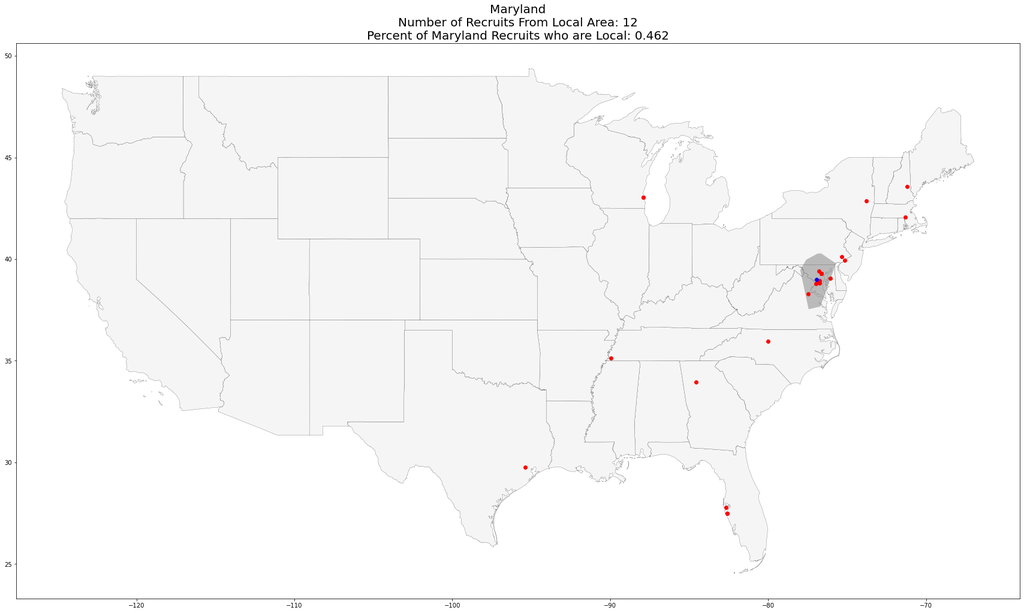

```python
# Plot Maryland as an example
plot_college_local_data("Maryland")
```

```python
# Join states and colleges
colleges_with_states = gdf_colleges_20.sjoin(states, how="left")

# Function takes a string with a college name and plots the college, its state, and its recruits over the U.S.
def plot_college_state_data(college):

    # Extract geodataframe for state that the college is in
    state = colleges_with_states[colleges_with_states["college"] == college]["NAME"].values[0]
    state_gdf = states[states["NAME"] == state]

    # Get the college's recruits
    gdf_recruits = gdf_h[gdf_h["college"] == college]

    # Get the college
    gdf_college = gdf_colleges_20[gdf_colleges_20["college"] == college]

    fig, ax = plt.subplots(figsize=(30,30))
    # Plot states
    states.plot(ax=ax,
            color='lavender',
            edgecolor='black',
            linewidth=0.2)
    # Plot state the college is in
    state_gdf.plot(ax=ax,
                  markersize=2,
                  color="grey",
                  alpha = 0.5)
    # Plot the recruits
    gdf_recruits.plot(ax=ax,
                      markersize=35,
                     color="red")
    # Plot the college
    gdf_college.plot(ax=ax,
                     markersize=35,
                    color="blue")

    # Get the number of recruits from the state and and the percent of recruits from the state
    n_in_state = gdf_colleges_20.loc[gdf_colleges_20["college"] == college]["num_in_state_recruits"].values[0]
    pct_in_state = gdf_colleges_20.loc[gdf_colleges_20["college"] == college]["pct_recruits_who_are_in_state"].values[0]

    # Display title
    plt.title(college + "\nNumber of Recruits From " + str(state) + ": " + str(n_in_state) + "\nPercent of " + str(college) +
              " recruits from "+ str(state) +": " + str(pct_in_state.round(3)), fontdict={'fontsize': 20})
```

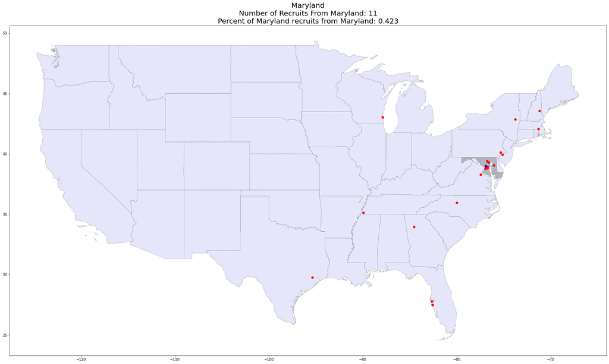

```python
# Plot Maryland as an example
plot_college_state_data("Maryland")
```

```python
# Function takes a college and plots its recruits on top of all the recruits to visualize the spatial clustering
def plot_college_cluster_data(college):

    # Get the recruits
    gdf_recruits = gdf_h[gdf_h["college"] == college]

    # Get the college point
    gdf_college = gdf_colleges_20[gdf_colleges_20["college"] == college]

    fig, ax = plt.subplots(figsize=(30,30))
    # Plot states
    states.plot(ax=ax,
            color='floralwhite',
            edgecolor='black',
            linewidth=0.2)
    # Plot all recruits' hometowns
    gdf_h.plot(ax=ax,
               markersize=1,
               color="grey",
               alpha=0.8)
    # Plot college's recruits
    gdf_recruits.plot(ax=ax,
                      markersize=35,
                     color="red",
                     alpha=1)
    # Plot college
    gdf_college.plot(ax=ax,
                     markersize=50,
                    color="blue")

    # Display title
    plt.title(college + "\nAverage p-value for z test comparing list of distances from recruits to college vs list of " +
              "distances from a random set of recruit points to college: " +
              str(gdf_colleges_20[gdf_colleges_20["college"]==college]["cluster_avg_p_value"].values[0].round(10)),
              fontdict={'fontsize': 20})
    plt.show()
```

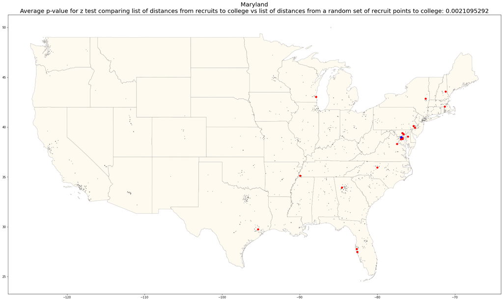

```python
# Plot Maryland as an example
plot_college_cluster_data("Maryland")
```

### Discussion

The original question was all about Maryland so lets see how Maryland did. In the maps above you can see all 6 of the relevant metrics but here they are again:

```python
# Get UMD statistics
gdf_colleges_20[gdf_colleges_20["college"] == "Maryland"][["college","num_recruits_from_nearest_100",
                                                           "pct_recruits_who_are_local","num_in_state_recruits",
                                                           "pct_recruits_who_are_in_state","cluster_avg_p_value",
                                                           "cluster_avg_significant"]]
```

|  | college | num_recruits_from_nearest_100 | pct_recruits_who_are_local | num_in_state_recruits | pct_recruits_who_are_in_state | cluster_avg_p_value | cluster_avg_significant |
| --- | --- | --- | --- | --- | --- | --- | --- |
| 37 | Maryland | 12 | 0.461538 | 11 | 0.423077 | 0.00211 | True |

Maryland was only able to recruit 12 of the 100 nearest high school basketball players who went on the play D1 basketball in the last 11 years. If we told my friends this, they might see this as proof that we suck at recruiting locally. 12 of 100 doesn't sound like a lot. However, when compared to all the other colleges in the analysis, that isn't half bad. Additionally, when considering that we only recruited 26 total players in that same time period, that means 46% or nearly half of our 3, 4, and 5 star recruits could be considered local. That was a lot better than I was expecting when I started this project. In terms of the in-state analysis, 11 of those 12 local recruits were from Maryland state (one local player was from NoVa). Meanwhile, Maryland had a very significant clustering relationship between the recruits' hometowns and their colleges, a relationship that is readily apparant in each of the above maps. Even for the non-local recruits, they came from Philadelphia or New England, with a few from other parts of the southern and eastern parts of the United States. Notably, we have no recruits from the West Coast, all together making it very unlikely this spatial distribution was random. So those are the raw numbers, but how did Maryland stack up compared to other colleges? Were they any better at recruiting locally?

```python
# Get ranks to compare with other colleges
gdf_colleges_20.rank(ascending= False).loc[[37]][["num_recruits_from_nearest_100","pct_recruits_who_are_local",
                                                  "num_in_state_recruits","pct_recruits_who_are_in_state"]]
```

|  | num_recruits_from_nearest_100 | pct_recruits_who_are_local | num_in_state_recruits | pct_recruits_who_are_in_state |
| --- | --- | --- | --- | --- |
| 37 | 10.5 | 6.0 | 17.0 | 15.0 |

In comparison to the 56 other colleges in the dataset, Maryland ranked high in both the local area and in-state metrics. Maryland was tied with Michigan for 10th on the number of recruits from the local area list. Our highest place on any list was 6th on the percent of recruits who are local list. This can be interpreted as Maryland being exceptionally reliant on recruiting local talent when compared to other colleges in the United States. We are also near the top of the lists for the in-state metrics, though not as high as in the local area analyses. This makes sense because Maryland is a small state so while schools in states like California, Texas, Georgia, and Florida had the ability to recruit players from their state who might not have been in their local area, Maryland did not. There are simply less people in the state so most of Maryland was already captured by the local area. Interestingly, for both the local area and in-state analyses, we ranked higher compared to other colleges in the percentage metric than the raw number metric. This makes sense because the number metrics take into account how good the school is at recruiting in general and Maryland is one of the worse recruiting schools in this dataset. Additionally, the fact that our percents are generally higher seems to indicate that even if we don't recruit an exceptionally high number of players from the DMV, we are more reliant on our local talent than other schools. Let's take a look at some other notable colleges, specifically Alabama, who topped the list for number of local recruits.

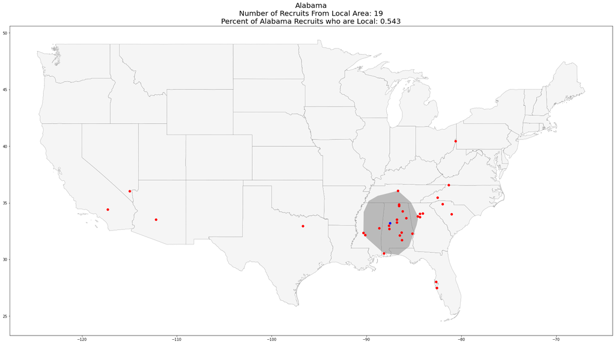

```python
plot_college_local_data("Alabama")
```

Alabama recruited a whopping 19 of their 100 nearest recruits in the last 10 years, with plenty of competition from neighboring schools like Auburn, Georgia, and Mississippi State. They rank high on all metrics I calculated (higher than Maryland), and have a very significant clustering relationship. I find this school particularly interesting, because Alabama has gone through four head coaches during this time period. I always thought the head coach had a major role in recruiting players, and assumed maybe one coach in particular had unlocked the secret to getting players to stay home. Instead, there must be some other factors at play, like maybe a proud state with a storied basketball tradition or a solid infrastructure of local scouts.

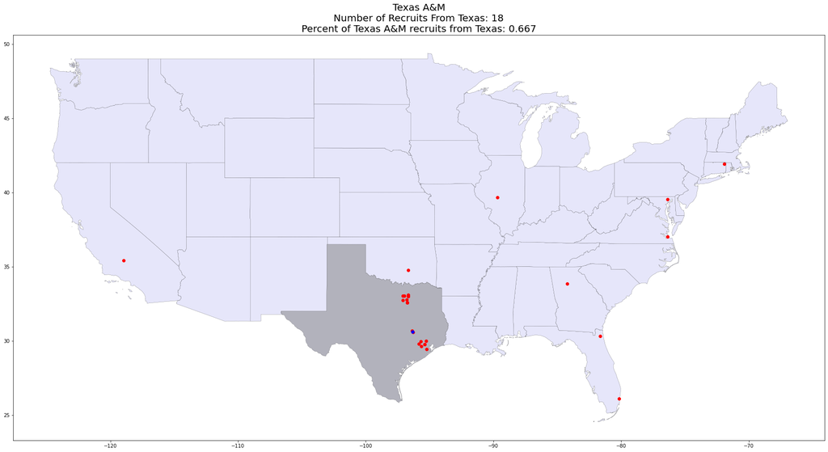

```python
plot_college_state_data("Texas A&M")
```

Meanwhile, Texas A&M has a very obvious in-state relationship. There are two huge clusters of recruits from Dallas and Houston. Amazingly, two thirds of their recruits in the last 11 years were from the state of Texas. While high on the in-state lists, Texas A&M wasn't as high up on the local area lists because their local area included Houston but failed to caputer the Dallas area. Like most schools in this analysis, Texas A&M exhibited a significant relationship in the clustering analysis.

What I find just as interesting however, are the schools that failed to exhibit significant clusting relationships, with a group of recruits that might as well have been random. The three colleges with the most recruits in the last 11 years, Kentucky, Duke, and Kansas, all failed to exhibit statistically significant clustering. Additionally, all 3 ranked low compared to other colleges in their ability to recruit (and their reliance on) local area and in state recruits.

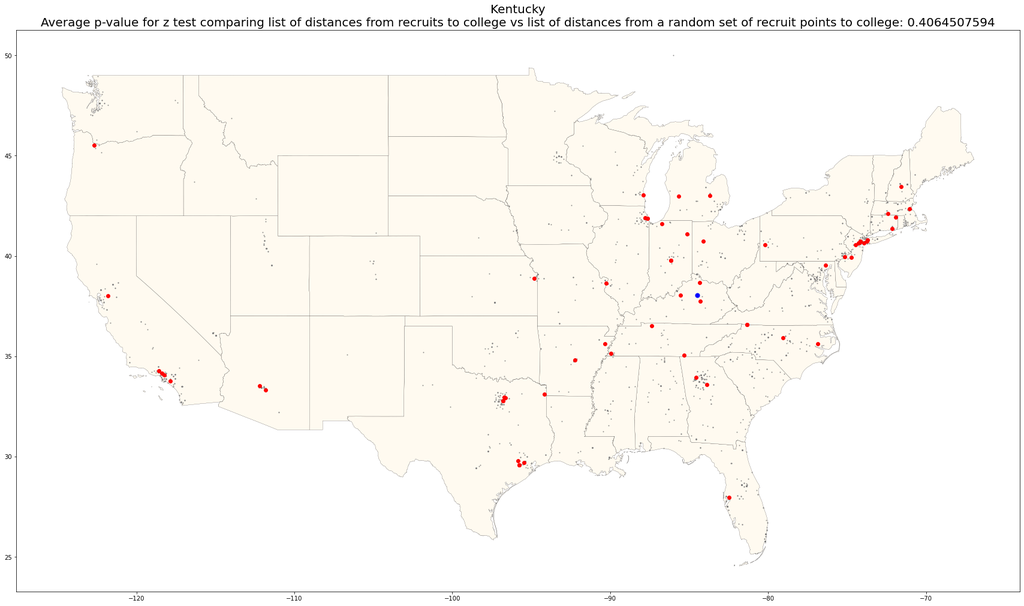

```python
plot_college_cluster_data("Kentucky")
```

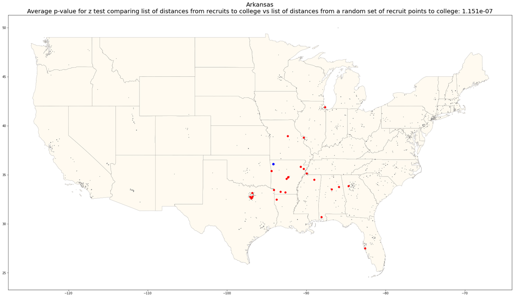

```python
plot_college_cluster_data("Arkansas")
```

```python
# Get ranks to compare Arkansas with other colleges
gdf_colleges_20.rank(ascending= False).loc[[16]][["num_recruits_from_nearest_100","pct_recruits_who_are_local",
                                                  "num_in_state_recruits","pct_recruits_who_are_in_state"]]
```

|  | num_recruits_from_nearest_100 | pct_recruits_who_are_local | num_in_state_recruits | pct_recruits_who_are_in_state |
| --- | --- | --- | --- | --- |
| 16 | 2.0 | 4.0 | 7.5 | 8.0 |

Arkansas ranked near the top on all 4 of the local area and in-state metrics. And they had a very low p-value and a striking map. All of their recruits came from the South, with the furthest players coming from Chicago and the Tampa Bay area. If there was a way for me to combine all the metrics I created during this project, I have a feeling Arkansas would sit at the top, with the most clear and obvious spatial relationship between to college and its recruits.

### Limitations

As previously mentioned, my definition of "local area" was far from perfect, and there are some issues I just can't fix. Let's take a look at Georgia and Oklahoma State.

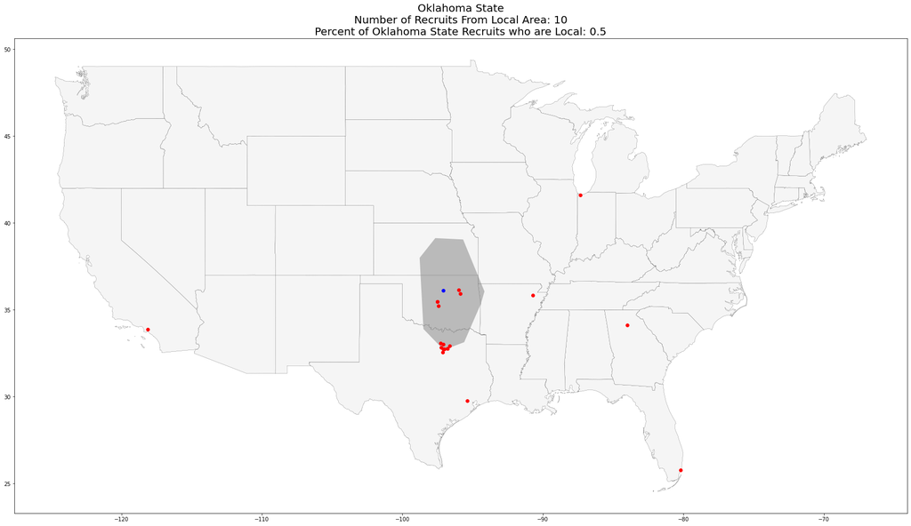

```python
plot_college_local_data("Oklahoma State")
```

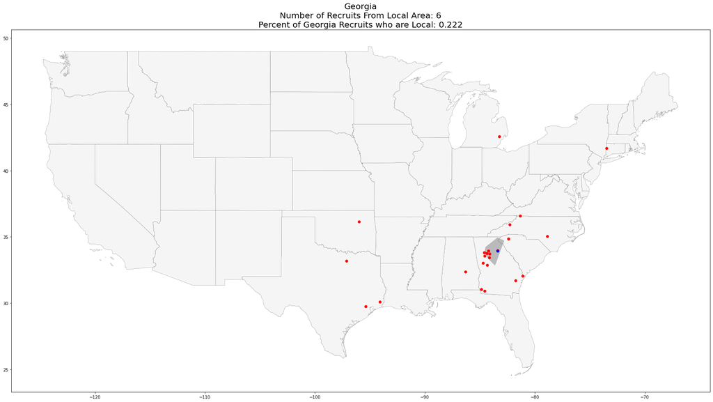

```python
plot_college_local_data("Georgia")
```

Both schools have incredibly obvious spatail relationships. In Oklahoma State's case, there's a Dallas-to-Stillwater basketball pipeline, and Georgia recruits a significant number of players from the Greater Atlanta Area. However in both cases, the local area analysis fails to fully capture all the recruits from these areas. 50% of OSU's recruits were from their local area but judging by the map you could argue it was even higher. Alternatively, you could also argue that Dallas shouldn't be considered local for Oklahoma State. After all, it's a 4 hour drive between the two cities. There is no right answer to whether or not Dallas should be considered local for OSU, and even if there was, how could I translate it to code in a way the fairly preserved local areas for everyone else? Anyways, while half of their recruits were classified as local, only 25% were in-state. Even with an obvious spatial relationship from the map, these two metrics are wildly different. In Georgia's case, it's the opposite. 22% of their recruits were local meanwhile 55% of their recruits were in-state. Which metric is better? It's different for each college. Both OSU and Georgia had statistically significant clustering between their recruits and the college, but the story is always incomplete without each of the 3 analyses and the map to paint the full picture. All three analyses, local area, in-state, and clustering, are flawed, but put together we can start to see the trends that emerge. Finally, another major limitation that seems almost impossible to overcome without access to another dataset is that a number of recruits will go to boarding schools to play high school basketball. There are a number of schools like Montverde, Oak Hill, and IMG Academy, who recruit high school players from around the country. On 247sports, this shows up as their hometown. I'm sure for some students, if you asked them where they were from, they wouldn't say the home town listed on 247sports. However, I doubt that the number of students who move for high school ultimately doesn't affect this analysis too much, but it does again raise the question as what counts as a home town and what counts as a local area.

### Further Research

No analysis ever feels complete, but with this one especially I can think of all sorts of questions I'd like to pursue if I had the time. I'd love to factor in the number of stars a recruit has into the local area analysis. Is Maryland recruiting local 3, 4, or 5 star plays at different rates? I'd also love dive deeper into the question of performance and local recruiting. Do schools actually perform better (i.e. win more games or win March Madness) if they recruit more or less locally? And finally I'd like to flip it around and look at it from the players side of things. Are there certain types of players (# of stars, graduation class, home town) who are more or less likely to stay home and play for a local college or go across the country? The possibilities are endless and each question opens the door for ten others.

### Final Conclusion

Looking at the results from the other colleges is interesting but let's go back and finally answer our original question: Is Maryland really that bad at recruiting local talent? Surprisingly (at least to me and my roommates) the answer is no. When comparing Maryland to 56 other high-recruiting D1 colleges, we are fairly above average on all metrics I created to measure local recruiting. We recruited 12 players from our local area in the past 11 years and 46% of our players are from there. 11 of them came from Maryland or 42% of our total recruits. Each of these numbers is higher than the averages of the other colleges in the dataset, and in my clustering analysis, I found a significant relationship between the distances from the recruits to Maryland, indicating that the spaital pattern of recruits' hometowns could not have been random. Additionally, along the way, I've found a number of other interesting relationships between certain colleges and the locations of their recruits, and I've opened the door for a many analyses that I'll pursue in the future. So yes, as Maryland students we should be proud of the amount of talent we have here in the DMV and the amount of players we already convince to stay home. However, that doesn't mean we can't keep improving, and hopefully during the Kevin Willard era, every DMV high school basketball player will have Maryland #1 on their list.